# R Notebook

# Background

**Possible variables related to HDLC (provided by Amy)**

- HDLC (period 03)
- Age (AGE)
- smoking (CURSMOKE)
- BMI
- glucose (GLUCOSE)
- PREVCHD
- cholesterol (TOTCHOL)

**HDLC values**  
it turns out that if HDLC

- `< 40` => not good
- `40 ~ 60` => normal
- `> 60` => very good

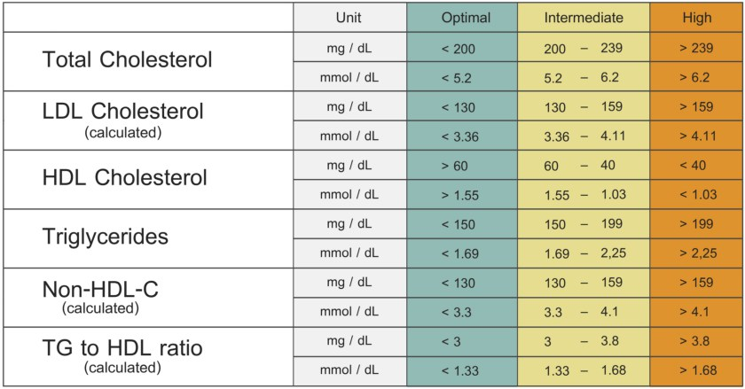

**our main question:**  
Is gender associated with HDL?

# set up environment

```r
library(GGally)
library(tidyverse)
```

```r
#datadir <- "D:\\GitRepo\\Statistics\\BIOS706\\Midterm"
#workdir <- "D:\\GitRepo\\Statistics\\BIOS706\\Proj"
datadir <- "/media/clint/Data/GitRepo/Statistics/BIOS706/Midterm"
workdir <- "/media/clint/Data/GitRepo/Statistics/BIOS706/Proj"
source("/media/clint/Data/GitRepo/Statistics/theme_publication.R")
setwd(workdir)
```

# Explore the data

### Read in the data

```r
dat_fham <- read_csv(file.path(datadir, "frmgham2.csv"))
```

all the variables

```r
colnames(dat_fham)
```

```
 [1] "RANDID"   "SEX"      "TOTCHOL"  "AGE"      "SYSBP"    "DIABP"    "CURSMOKE" "CIGPDAY"  "BMI"      "DIABETES"
[11] "BPMEDS"   "HEARTRTE" "GLUCOSE"  "educ"     "PREVCHD"  "PREVAP"   "PREVMI"   "PREVSTRK" "PREVHYP"  "TIME"
[21] "PERIOD"   "HDLC"     "LDLC"     "DEATH"    "ANGINA"   "HOSPMI"   "MI_FCHD"  "ANYCHD"   "STROKE"   "CVD"
[31] "HYPERTEN" "TIMEAP"   "TIMEMI"   "TIMEMIFC" "TIMECHD"  "TIMESTRK" "TIMECVD"  "TIMEDTH"  "TIMEHYP"
```

### explore the values in HDLC

- how many observations in period 03
- how many missing for HDL

```
Num of Observation in each PERIOD
```

```
   1    2    3
4434 3930 3263
```

```
Num of NA in HDLC in each PERIOD
```

```
   1    2    3
4434 3930  236
```

The histogram shows that there is an extreme high value. Currently I have seen report showing that the HDLC can be up to 100.

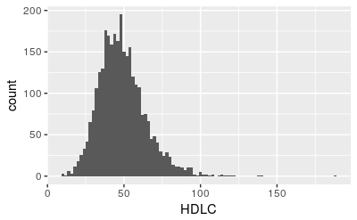

```r
gp <- ggplot(dat_fham, aes(x = HDLC)) +
    geom_histogram(binwidth = 2)
gp
```

Preprocess

```r
dat <- dat_fham
# 1 = Men, 2 = Women
dat$SEX_LAB <- c("Male", "Female")[dat$SEX]
# 1 = Men, 2 = Women
dat$HDLC_LAB <- cut(dat$HDLC, breaks = c(0, 40, 60, 200), labels = c("Too Low", "Normal", "High"))
# filter out NA values in HDLC
dat_prep <- dat %>% filter(!is.na(HDLC))
```

check period

```r
table(dat_prep$PERIOD)
```

```
   3
3027
```

information: sex

```r
table(dat_prep$SEX_LAB)
```

```
Female   Male
  1723   1304
```

information: HDLC

```
Too Low  Normal    High
    918    1513     596
```

we will also perform chi-square test below

# EDA

it turns out that most variables do not correlated with HDLC

[output not shown]

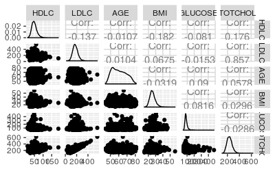

```r
#dat <- dat_prep %>% select(HDLC, AGE, CURSMOKE, BMI, GLUCOSE, PREVCHD, TOTCHOL)
dat <- dat_prep %>% select(HDLC, LDLC, AGE, BMI, GLUCOSE, TOTCHOL)
ggpairs(dat)
```

# gender vs HDLC

```r
gp <- ggplot(dat_prep, aes(y = HDLC, x = SEX_LAB, fill = SEX_LAB)) +
    geom_boxplot() +
    xlab("Gender") +
    theme_Publication() +
    theme(legend.position="none")
```

```
`legend.margin` must be specified using `margin()`. For the old behavior use legend.spacing
```

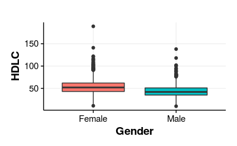

```r
gp
```

```r
gp <- ggplot(dat_prep, aes(y = HDLC, x = HDLC_LAB, fill = SEX_LAB)) +
    geom_boxplot() +
    geom_jitter(alpha = 0.05) +
    xlab("HDLC Status") +
    labs(fill = "Gender") +
    theme_Publication() +
    theme(
        legend.position="right",
        legend.direction = "vertical",
        legend.key.width = unit(2, "line"),
        legend.key.height = unit(2, "line"))
```

```
`legend.margin` must be specified using `margin()`. For the old behavior use legend.spacing
```

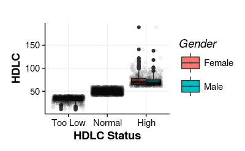

```r
gp
```

```r
gp <- ggplot(dat_prep, aes(x = HDLC, fill = SEX_LAB)) +
    geom_histogram() +
    xlab("Values") +
    ylab("Count") +
    theme_Publication() +
    labs(fill="Gender") +
    #theme(legend.title = "Gender") +
    facet_grid(SEX_LAB~.)
```

```
`legend.margin` must be specified using `margin()`. For the old behavior use legend.spacing
```

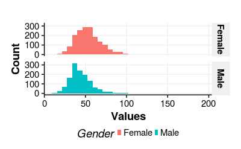

```r
gp
```

# two sample test

Below we found that both t test and wilcoxin test (two-sided test) show the HDLC is significant between male and female.

- t test
  - t statistic: 18.69
  - p-value < 2.2e-16
  - 95% CI: (8.89, 10.97)
- Wilcoxin
  - W statistic: 1562400
  - p-value < 2.2e-16

```r
tmp <- split(dat_prep$HDLC, dat_prep$SEX_LAB)
```

```r
t.test(tmp$Female, tmp$Male, alternative = "two.sided")
```

```
    Welch Two Sample t-test

data:  tmp$Female and tmp$Male
t = 18.692, df = 2995.1, p-value < 2.2e-16
alternative hypothesis: true difference in means is not equal to 0
95 percent confidence interval:
  8.889611 10.973205
sample estimates:
mean of x mean of y
 53.64306  43.71166
```

```
    Wilcoxon rank sum test with continuity correction

data:  tmp$Female and tmp$Male
W = 1562400, p-value < 2.2e-16
alternative hypothesis: true location shift is not equal to 0
```

# chi-square test

```r
tab <- table(dat_prep$HDLC_LAB, dat_prep$SEX_LAB)
print(tab)
```

```
          Female Male
  Too Low    333  585
  Normal     916  597
  High       474  122
```

```r
res <- chisq.test(tab)
res
```

```
    Pearson's Chi-squared test

data:  tab
X-squared = 291.92, df = 2, p-value < 2.2e-16
```

```r
#res$expected
```